# Intervalos de confianza y Contraste de hipótesis

## 1. Cargar un juego de datos

```r
nombreruta_PEC2 <- paste(getwd(),"/House.csv", sep = "")

X <- read.csv(nombreruta_PEC2, encoding="UTF-8", header=TRUE, sep=",", na.strings="NA", dec=".", strip.white=TRUE)
names(X)
```

```
## [1] "price"    "sqrft"    "colonial"
```

```r
colnames(X)<-c("precio","tamano","colonial")
names(X)
```

```
## [1] "precio"   "tamano"   "colonial"
```

## 2. Consulta de los datos un juego de datos

#### 2.1 Consultar el resumen de la variable Precio(price) y el tipo de datos.

```r
summary(X$precio)
```

```
##    Min. 1st Qu.  Median    Mean 3rd Qu.    Max.
##  111000  230000  265500  293500  326200  725000
```

```r
class(X$precio)
```

```
## [1] "integer"
```

#### 2.2 Mostrar un boxplot con la distribución de la variable Precio.

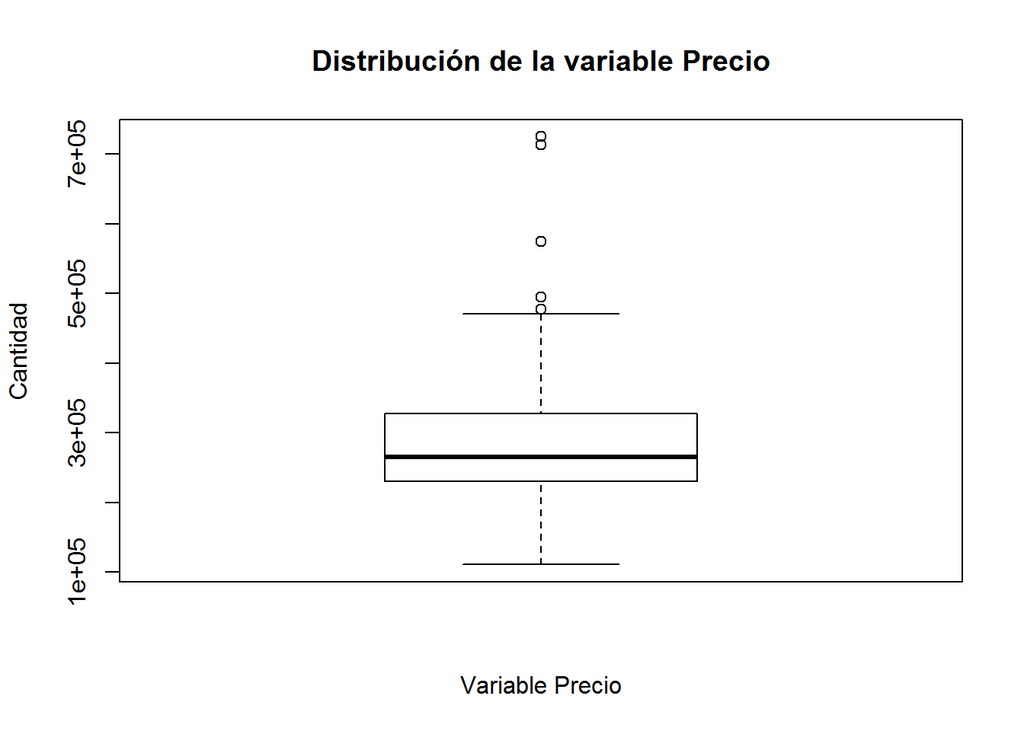

```r
boxplot(X$precio, main = "Distribución de la variable Precio", xlab = "Variable Precio", ylab = "Cantidad")
```

## 3. Descripción de la muestra

#### 3.1 Calcular la media y la desviación muestral de la variable Precio.

```r
# media de la muestra
mm <- mean(X$precio)
mm
```

```
## [1] 293546
```

```r
# Desviación de la población (muestra)
dm <- sd(X$precio)
dm
```

```
## [1] 102713.4
```

## 4 Calculamos el intervalo de confianza de la media de precio de la población con un nivel de confianza de 95%.

#### 4.1. Calcular el intervalo de confianza de 95% de la media poblacional. Suponed que conocéis la desviación estándard de la población (usad la desviación de la muestra) y podéis usar el estadístico z. Se recomienda detallar todos los pasos e imprimir a pantalla los resultados de los cálculos parciales. Finalmente, imprimir el valor del intervalo de confianza.

Calculamos el intervalo de confianza para el supuesto con desviación estandar conocida.

```r
# tamaño de la muestra
n <- length(X$precio)

# p es % del nivel de confianza que queremos obtener
nc <- 95
p <- nc/100

# Obtenemos el tamaño del intervalo
alfa <- 1-p

# Obtenemos el tamaño de uno de los dos extremos exteriores del intervalo
alfa2 <- alfa/2

# Obtenemos z
z_alfa <- qnorm(1-alfa2)
z_alfa
```

```
## [1] 1.959964
```

```r
# Obtenemos el límite inferior
lim.inf <- mm-z_alfa*dm/sqrt(n)
lim.inf
```

```
## [1] 272085.8
```

```r
# Obtenemos el límite superior
lim.sup <- mm+z_alfa*dm/sqrt(n)
lim.sup
```

```
## [1] 315006.2
```

#### 4.2. Repetir los cálculos para el estadístico t de Student.

```r
#Obtenemos el tamaño del intervalo a partir de valores conocidos tamaño muestra, desviación estandar y alfa/2
error<- qt((1-alfa/2), df=n-1)*dm/sqrt(n)

# Obtenemos el límite inferior
extIzq<- mm-error
extIzq
```

```
## [1] 271783.1
```

```r
# Obtenemos el límite superior
extDer<- mm+error
extDer
```

```
## [1] 315308.9
```

#### 4.3. Responder a las siguientes preguntas: ¿Es más restrictivo el intervalo de confianza usando la distribución normal o la distribución t de Student? ¿Por qué? ¿Qué intervalo de confianza crees que es el más adecuado con nuestros datos y por qué? Contestar brevemente.

Es más restrictiva la distribución normal porque la distribución t student tiene mayor área en los extremos consecuencia del desconocimiento del valor de sigma por lo que se emplea la desviación estandar muestral para estimarlo haciendo a los valores de “t” de student más variables que los “z” de la normal. Para el supuesto planteado y con una cantidad muestral mayor de 30 creo que es más oportuno realizar el intervalo de confianza usando la distribución normal.

## 5. Análisis de correlaciones ¿Hay correlación entre los precios y los tamaños de las viviendas?

#### 5.1. Mostramos un scatter plot con las dos variables: Tamaño y Precio para ver visualmente si hay correlación lineal.

Se puede apreciar visualmente que existe una relación entre el tamaño de la vivienda y su precio.

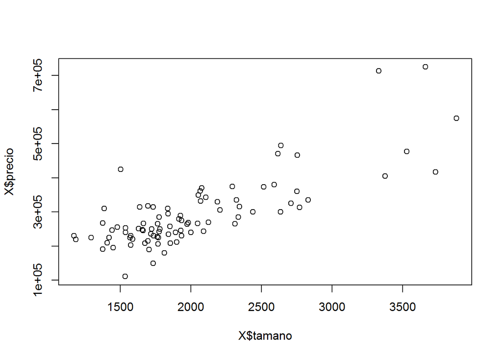

```r
plot(X$tamano, X$precio)
```

#### 5.2. Calculamos el coeficiente de correlación lineal entre estas dos variables. Para ello, usamos la función cor de R.

```r
cor(X$tamano, X$precio)
```

```
## [1] 0.7879065
```

#### 5.3. Razonar sobre el resultado del coeficiente obtenido en relación al valor y sobretodo al signo (positivo o negativo).

Con un coeficiente de 0.7879 podemos decir que existe entre las variables tamaño y precio una correlación bastante fuerte y de signo positivo pues tiende a 1.

## 6. Regresión: ¿Podemos suponer que el tamaño de la vivienda es una buena variable explicativa para poder predecir el comportamiento del precio de la vivienda?

#### 6.1. Calcular la regresión con un modelo lineal, donde el precio de la vivienda se relaciona con tamaño de la vivienda. Usar la función lm de R.

```r
preciolm <- lm(X$precio ~ X$tamano)
```

#### 6.2. Mostrar el resultado del modelo lineal obtenido, los coeficientes, etc.

```r
# Mostramos el resultado del modelo lineal obtenido.
preciolm
```

```
##
## Call:
## lm(formula = X$precio ~ X$tamano)
##
## Coefficients:
## (Intercept)     X$tamano
##     11204.1        140.2
```

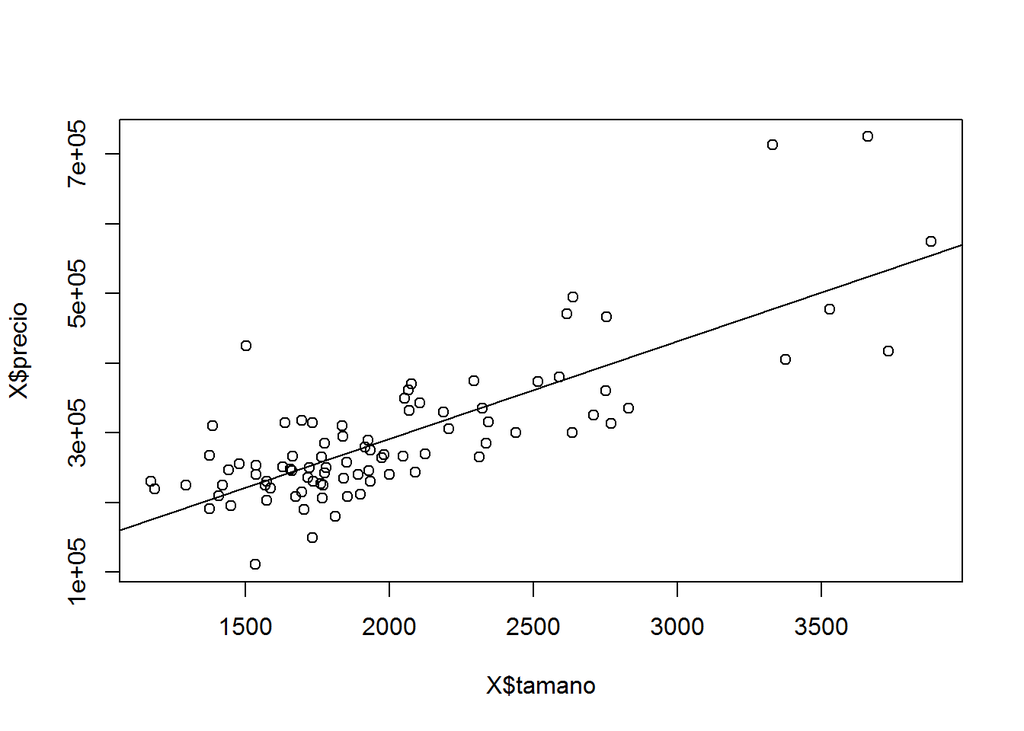

```r
# Ploteamos la pendiente obtenida
plot(X$tamano, X$precio)
abline(preciolm)
```

```r
# Constante del modelo lineal(intercept)
preciolm$coefficients[[1]]
```

```
## [1] 11204.14
```

```r
#Coeficiente multiplicativo
preciolm$coefficients[[2]]
```

```
## [1] 140.211
```

#### 6.3. Estimamos el precio de la vivienda que tendría una vivienda de 2000 pies al cuadrado, a partir de los coeficientes del modelo lineal calculado.

```r
tVivienda <- 2000
pVivienda <- preciolm$coefficients[[1]] + preciolm$coefficients[[2]]*tVivienda
data.frame(pVivienda, tVivienda)
```

```
##   pVivienda tVivienda
## 1  291626.1      2000
```

#### 6.4. Mostrar el coeficiente de determinación del modelo lineal e interpretar el coeficiente.

```r
# El coeficiente de determinación se obtiene a partir de:
spreciolm <- summary(preciolm)

# identificado como Multiple R-Squared
spreciolm$r.squared
```

```
## [1] 0.6207967
```

```r
# Corroboramos que su valor es igual a la correlación al cuadrado
cor(X$tamano, X$precio)^2
```

```
## [1] 0.6207967
```

#### 6.5. Interpretar los resultados obtenidos.

```r
summary(preciolm)
```

```
##
## Call:
## lm(formula = X$precio ~ X$tamano)
##
## Residuals:
##     Min      1Q  Median      3Q     Max
## -117112  -36348   -6503   31701  235253
##
## Coefficients:
##             Estimate Std. Error t value Pr(>|t|)
## (Intercept) 11204.14   24742.61   0.453    0.652
## X$tamano      140.21      11.82  11.866   <2e-16 ***
## ---
## Signif. codes:  0 '***' 0.001 '**' 0.01 '*' 0.05 '.' 0.1 ' ' 1
##
## Residual standard error: 63620 on 86 degrees of freedom
## Multiple R-squared:  0.6208, Adjusted R-squared:  0.6164
## F-statistic: 140.8 on 1 and 86 DF,  p-value: < 2.2e-16
```

```r
confint(preciolm)
```

```
##                   2.5 %     97.5 %
## (Intercept) -37982.5312 60390.8208
## X$tamano       116.7203   163.7017
```

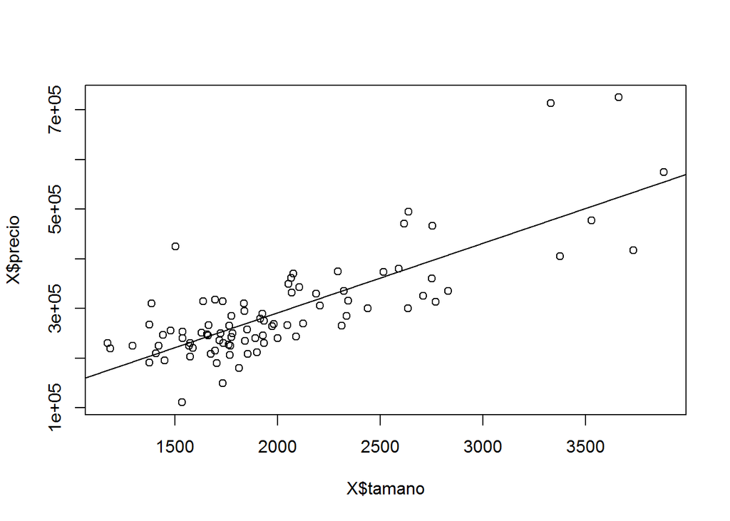

```r
plot(X$tamano, X$precio)
abline(preciolm)
```

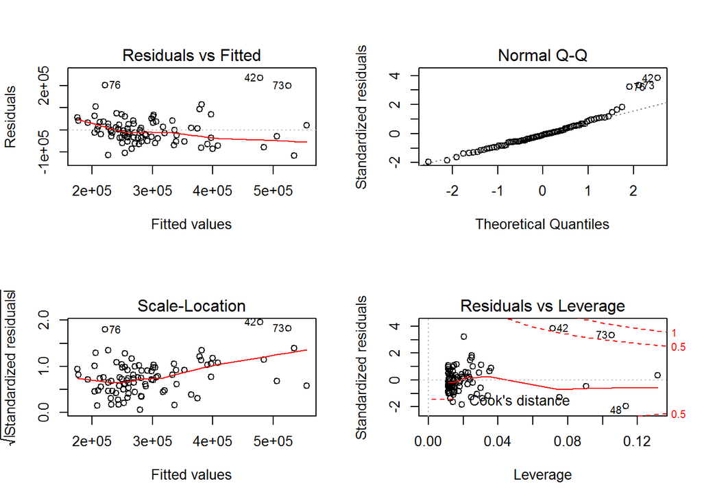

```r
par(mfrow=c(2,2))
plot(lm(X$precio ~ X$tamano))
```

## 7. Contrastes de hipótesis: ¿El precio medio de las viviendas es de 200,000 dólares o mayor?

#### 7.1. Escribir la hipótesis nula y la hipótesis alternativa.

H0: Mu = 200000 # Hipótesis nula  
H1: Mu > 200000 # Hipótesis alternativa

#### 7.2. Recordamos que no conocemos la Varianza poblacional. Con un nivel de confianza del 95%, ¿Se rechaza o no la H0? Razonar sobre el resultado.

```r
# Obtenemos el valor de la región de rechazo para un nivel de confianza del 95%
alfa95 <- 0.05
region <- qt((1-alfa95), df=n-1)
region
```

```
## [1] 1.662557
```

```r
# Obtenemos el estadístico
estadistico <- (mm-200000)/(dm/sqrt(n))
estadistico
```

```
## [1] 8.543571
```

Obtenemos el límite por la derecha para la región de alfa = 0.05 dando un valor de 1.662557.  
El estadístico de contraste hallado es t=8.543571 por lo que claramente el estadístico se encuentra en la región de rechazo lo que haría que descartásemos la hipótesis nula para aceptar H1.

#### 7.3. Repetir el cálculo para un nivel de confianza del 80%.

```r
# Obtenemos el valor de la región de rechazo para un nivel de confianza del 80%
alfa80 <- 0.20
region <- qt((1-alfa80), df=n-1)
region
```

```
## [1] 0.8457723
```

```r
# Obtenemos el estadístico
estadistico <- (mm-200000)/(dm/sqrt(n))
estadistico
```

```
## [1] 8.543571
```

#### 7.4. Razonar sobre el resultado comparando los niveles de confianza de 95% y 80%.

Del resultado para estadistico = 8.5435… Para nivel de confianza 95%: region = 1.66  
Para nivel de confianza 80%: region = 0.84

Podemos apreciar que el valor del nivel de confianza y la region son directamente proporcionales por lo que cuanto más seguro queramos estar mayor region va a ser necesaria, de esto podemos deducir que si no se cumplia H0 para el supuesto de confianza del 95% no se cumpliría para ninguno menor.